# Risk Factor Analysis

## Outcome Variable

**Outcome Variable:** stunted

## Predictor Variables

**Intervention Variable:** enwast

**Adjustment Set:**

- arm
- sex
- W_mage
- meducyrs
- feducyrs
- vagbrth
- single
- brthmon
- W_parity
- delta_W_mage
- delta_meducyrs
- delta_feducyrs
- delta_vagbrth
- delta_single
- delta_brthmon
- delta_W_parity

## Stratifying Variables

The analysis was stratified on these variable(s):

- agecat
- studyid
- country

## Data Summary

| agecat | studyid | country | enwast | stunted | n_cell | n |
| --- | --- | --- | --- | --- | --- | --- |
| Birth | CMC-V-BCS-2002 | INDIA | 0 | 0 | 66 | 87 |
| Birth | CMC-V-BCS-2002 | INDIA | 0 | 1 | 9 | 87 |
| Birth | CMC-V-BCS-2002 | INDIA | 1 | 0 | 9 | 87 |
| Birth | CMC-V-BCS-2002 | INDIA | 1 | 1 | 3 | 87 |
| Birth | CMIN | BANGLADESH | 0 | 0 | 14 | 19 |
| Birth | CMIN | BANGLADESH | 0 | 1 | 1 | 19 |
| Birth | CMIN | BANGLADESH | 1 | 0 | 3 | 19 |
| Birth | CMIN | BANGLADESH | 1 | 1 | 1 | 19 |
| Birth | COHORTS | GUATEMALA | 0 | 0 | 540 | 762 |
| Birth | COHORTS | GUATEMALA | 0 | 1 | 24 | 762 |
| Birth | COHORTS | GUATEMALA | 1 | 0 | 198 | 762 |
| Birth | COHORTS | GUATEMALA | 1 | 1 | 0 | 762 |
| Birth | COHORTS | INDIA | 0 | 0 | 4772 | 6231 |
| Birth | COHORTS | INDIA | 0 | 1 | 325 | 6231 |
| Birth | COHORTS | INDIA | 1 | 0 | 1074 | 6231 |
| Birth | COHORTS | INDIA | 1 | 1 | 60 | 6231 |
| Birth | COHORTS | PHILIPPINES | 0 | 0 | 2373 | 2910 |
| Birth | COHORTS | PHILIPPINES | 0 | 1 | 75 | 2910 |
| Birth | COHORTS | PHILIPPINES | 1 | 0 | 451 | 2910 |
| Birth | COHORTS | PHILIPPINES | 1 | 1 | 11 | 2910 |
| Birth | CONTENT | PERU | 0 | 0 | 2 | 2 |
| Birth | CONTENT | PERU | 0 | 1 | 0 | 2 |
| Birth | CONTENT | PERU | 1 | 0 | 0 | 2 |
| Birth | CONTENT | PERU | 1 | 1 | 0 | 2 |
| Birth | EE | PAKISTAN | 0 | 0 | 120 | 180 |
| Birth | EE | PAKISTAN | 0 | 1 | 35 | 180 |
| Birth | EE | PAKISTAN | 1 | 0 | 20 | 180 |
| Birth | EE | PAKISTAN | 1 | 1 | 5 | 180 |
| Birth | GMS-Nepal | NEPAL | 0 | 0 | 450 | 645 |
| Birth | GMS-Nepal | NEPAL | 0 | 1 | 59 | 645 |

[output cut: 298 more lines]

The following strata were considered:

- agecat: 24 months, studyid: CMC-V-BCS-2002, country: INDIA
- agecat: 24 months, studyid: CMIN, country: BANGLADESH
- agecat: 24 months, studyid: COHORTS, country: GUATEMALA
- agecat: 24 months, studyid: COHORTS, country: INDIA
- agecat: 24 months, studyid: COHORTS, country: PHILIPPINES
- agecat: 24 months, studyid: CONTENT, country: PERU
- agecat: 24 months, studyid: EE, country: PAKISTAN
- agecat: 24 months, studyid: GMS-Nepal, country: NEPAL
- agecat: 24 months, studyid: IRC, country: INDIA
- agecat: 24 months, studyid: JiVitA-3, country: BANGLADESH
- agecat: 24 months, studyid: JiVitA-4, country: BANGLADESH
- agecat: 24 months, studyid: Keneba, country: GAMBIA
- agecat: 24 months, studyid: LCNI-5, country: MALAWI
- agecat: 24 months, studyid: MAL-ED, country: BANGLADESH
- agecat: 24 months, studyid: MAL-ED, country: BRAZIL
- agecat: 24 months, studyid: MAL-ED, country: INDIA
- agecat: 24 months, studyid: MAL-ED, country: NEPAL
- agecat: 24 months, studyid: MAL-ED, country: PERU
- agecat: 24 months, studyid: MAL-ED, country: SOUTH AFRICA
- agecat: 24 months, studyid: MAL-ED, country: TANZANIA, UNITED REPUBLIC OF
- agecat: 24 months, studyid: NIH-Birth, country: BANGLADESH
- agecat: 24 months, studyid: NIH-Crypto, country: BANGLADESH
- agecat: 24 months, studyid: PROBIT, country: BELARUS
- agecat: 24 months, studyid: PROVIDE, country: BANGLADESH
- agecat: 24 months, studyid: TanzaniaChild2, country: TANZANIA, UNITED REPUBLIC OF
- agecat: 24 months, studyid: ZVITAMBO, country: ZIMBABWE
- agecat: 6 months, studyid: CMC-V-BCS-2002, country: INDIA
- agecat: 6 months, studyid: CMIN, country: BANGLADESH
- agecat: 6 months, studyid: COHORTS, country: GUATEMALA
- agecat: 6 months, studyid: COHORTS, country: INDIA
- agecat: 6 months, studyid: COHORTS, country: PHILIPPINES
- agecat: 6 months, studyid: CONTENT, country: PERU
- agecat: 6 months, studyid: EE, country: PAKISTAN
- agecat: 6 months, studyid: GMS-Nepal, country: NEPAL
- agecat: 6 months, studyid: Guatemala BSC, country: GUATEMALA
- agecat: 6 months, studyid: IRC, country: INDIA
- agecat: 6 months, studyid: JiVitA-3, country: BANGLADESH
- agecat: 6 months, studyid: JiVitA-4, country: BANGLADESH
- agecat: 6 months, studyid: Keneba, country: GAMBIA
- agecat: 6 months, studyid: LCNI-5, country: MALAWI
- agecat: 6 months, studyid: MAL-ED, country: BANGLADESH
- agecat: 6 months, studyid: MAL-ED, country: BRAZIL
- agecat: 6 months, studyid: MAL-ED, country: INDIA
- agecat: 6 months, studyid: MAL-ED, country: NEPAL
- agecat: 6 months, studyid: MAL-ED, country: PERU
- agecat: 6 months, studyid: MAL-ED, country: SOUTH AFRICA
- agecat: 6 months, studyid: MAL-ED, country: TANZANIA, UNITED REPUBLIC OF
- agecat: 6 months, studyid: NIH-Birth, country: BANGLADESH
- agecat: 6 months, studyid: NIH-Crypto, country: BANGLADESH
- agecat: 6 months, studyid: PROBIT, country: BELARUS
- agecat: 6 months, studyid: PROVIDE, country: BANGLADESH
- agecat: 6 months, studyid: ResPak, country: PAKISTAN
- agecat: 6 months, studyid: SAS-CompFeed, country: INDIA
- agecat: 6 months, studyid: SAS-FoodSuppl, country: INDIA
- agecat: 6 months, studyid: TanzaniaChild2, country: TANZANIA, UNITED REPUBLIC OF
- agecat: 6 months, studyid: ZVITAMBO, country: ZIMBABWE
- agecat: Birth, studyid: CMC-V-BCS-2002, country: INDIA
- agecat: Birth, studyid: CMIN, country: BANGLADESH
- agecat: Birth, studyid: COHORTS, country: GUATEMALA
- agecat: Birth, studyid: COHORTS, country: INDIA
- agecat: Birth, studyid: COHORTS, country: PHILIPPINES
- agecat: Birth, studyid: CONTENT, country: PERU
- agecat: Birth, studyid: EE, country: PAKISTAN
- agecat: Birth, studyid: GMS-Nepal, country: NEPAL
- agecat: Birth, studyid: IRC, country: INDIA
- agecat: Birth, studyid: JiVitA-3, country: BANGLADESH
- agecat: Birth, studyid: JiVitA-4, country: BANGLADESH
- agecat: Birth, studyid: Keneba, country: GAMBIA
- agecat: Birth, studyid: MAL-ED, country: BANGLADESH
- agecat: Birth, studyid: MAL-ED, country: BRAZIL
- agecat: Birth, studyid: MAL-ED, country: INDIA
- agecat: Birth, studyid: MAL-ED, country: NEPAL
- agecat: Birth, studyid: MAL-ED, country: PERU
- agecat: Birth, studyid: MAL-ED, country: SOUTH AFRICA
- agecat: Birth, studyid: MAL-ED, country: TANZANIA, UNITED REPUBLIC OF
- agecat: Birth, studyid: NIH-Birth, country: BANGLADESH
- agecat: Birth, studyid: NIH-Crypto, country: BANGLADESH
- agecat: Birth, studyid: PROBIT, country: BELARUS
- agecat: Birth, studyid: PROVIDE, country: BANGLADESH
- agecat: Birth, studyid: ResPak, country: PAKISTAN
- agecat: Birth, studyid: SAS-CompFeed, country: INDIA
- agecat: Birth, studyid: ZVITAMBO, country: ZIMBABWE

### Dropped Strata

Some strata were dropped due to rare outcomes:

- agecat: Birth, studyid: CMC-V-BCS-2002, country: INDIA
- agecat: Birth, studyid: CMIN, country: BANGLADESH
- agecat: Birth, studyid: COHORTS, country: GUATEMALA
- agecat: Birth, studyid: CONTENT, country: PERU
- agecat: Birth, studyid: IRC, country: INDIA
- agecat: Birth, studyid: MAL-ED, country: BANGLADESH
- agecat: Birth, studyid: MAL-ED, country: BRAZIL
- agecat: Birth, studyid: MAL-ED, country: INDIA
- agecat: Birth, studyid: MAL-ED, country: NEPAL
- agecat: Birth, studyid: MAL-ED, country: PERU
- agecat: Birth, studyid: MAL-ED, country: SOUTH AFRICA
- agecat: Birth, studyid: MAL-ED, country: TANZANIA, UNITED REPUBLIC OF
- agecat: Birth, studyid: PROBIT, country: BELARUS
- agecat: Birth, studyid: ResPak, country: PAKISTAN
- agecat: 6 months, studyid: CONTENT, country: PERU
- agecat: 6 months, studyid: Guatemala BSC, country: GUATEMALA
- agecat: 6 months, studyid: MAL-ED, country: BRAZIL
- agecat: 6 months, studyid: MAL-ED, country: NEPAL
- agecat: 6 months, studyid: MAL-ED, country: PERU
- agecat: 6 months, studyid: MAL-ED, country: SOUTH AFRICA
- agecat: 6 months, studyid: MAL-ED, country: TANZANIA, UNITED REPUBLIC OF
- agecat: 24 months, studyid: CONTENT, country: PERU
- agecat: 24 months, studyid: LCNI-5, country: MALAWI
- agecat: 24 months, studyid: MAL-ED, country: BRAZIL
- agecat: 24 months, studyid: MAL-ED, country: PERU
- agecat: 24 months, studyid: MAL-ED, country: SOUTH AFRICA
- agecat: 24 months, studyid: MAL-ED, country: TANZANIA, UNITED REPUBLIC OF
- agecat: 24 months, studyid: TanzaniaChild2, country: TANZANIA, UNITED REPUBLIC OF

## Methods Detail

We’re interested in the causal parameters $E[Y_a]$ for all values of $a \in \mathcal{A}$. These parameters represent the mean outcome if, possibly contrary to fact, we intervened to set all units to have $A=a$. Under the randomization and positivity assumptions, these are identified by the statistical parameters $\psi_a=E_W[E_{Y|A,W}(Y|A=a,W)]$. In addition, we’re interested in the mean of $Y$, $E[Y]$ under no intervention (the observed mean). We will estimate these parameters by using SuperLearner to fit the relevant likelihood factors – $E_{Y|A,W}(Y|A=a,W)$ and $p(A=a|W)$, and then updating our likelihood fit using a joint TMLE.

For unadjusted analyses ($W=\{\}$), initial likelihoods were estimated using Lrnr_glm to estimate the simple $E(Y|A)$ and Lrnr_mean to estimate $p(A)$. For adjusted analyses, a small library containing Lrnr_glmnet, Lrnr_xgboost, and Lrnr_mean was used.

Having estimated these parameters, we will then use the delta method to estimate relative risks and attributable risks relative to a prespecified baseline level of $A$.

# Results Detail

## Results Plots

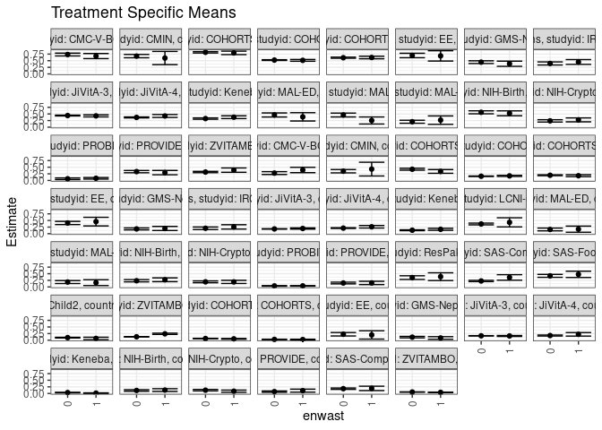

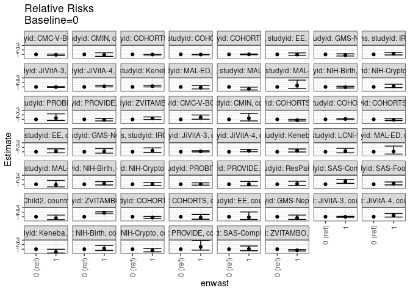

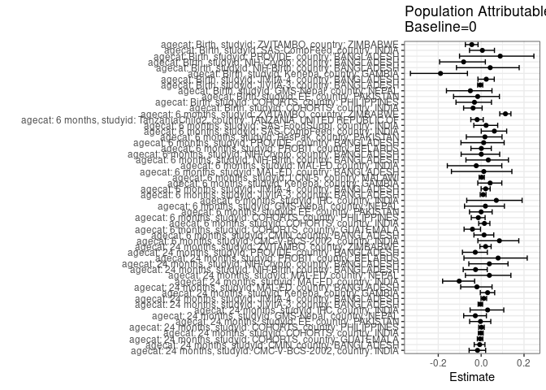

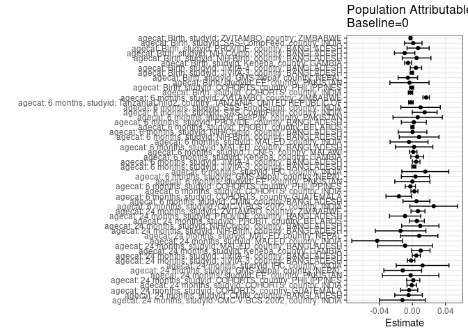

## Results Table

### Parameter: TSM

| agecat | studyid | country | intervention_level | baseline_level | estimate | ci_lower | ci_upper |
| --- | --- | --- | --- | --- | --- | --- | --- |
| Birth | COHORTS | INDIA | 0 | NA | 0.0641161 | 0.0573793 | 0.0708529 |
| Birth | COHORTS | INDIA | 1 | NA | 0.0516598 | 0.0384819 | 0.0648377 |
| Birth | COHORTS | PHILIPPINES | 0 | NA | 0.0304772 | 0.0236684 | 0.0372860 |
| Birth | COHORTS | PHILIPPINES | 1 | NA | 0.0246839 | 0.0104239 | 0.0389438 |
| Birth | EE | PAKISTAN | 0 | NA | 0.2258065 | 0.1598002 | 0.2918127 |
| Birth | EE | PAKISTAN | 1 | NA | 0.2000000 | 0.0427655 | 0.3572345 |
| Birth | GMS-Nepal | NEPAL | 0 | NA | 0.1156140 | 0.0877524 | 0.1434755 |
| Birth | GMS-Nepal | NEPAL | 1 | NA | 0.0849557 | 0.0364691 | 0.1334423 |
| Birth | JiVitA-3 | BANGLADESH | 0 | NA | 0.1664758 | 0.1601274 | 0.1728243 |
| Birth | JiVitA-3 | BANGLADESH | 1 | NA | 0.1610048 | 0.1436617 | 0.1783479 |
| Birth | JiVitA-4 | BANGLADESH | 0 | NA | 0.1761911 | 0.1573477 | 0.1950344 |
| Birth | JiVitA-4 | BANGLADESH | 1 | NA | 0.2225973 | 0.1564206 | 0.2887740 |
| Birth | Keneba | GAMBIA | 0 | NA | 0.0335753 | 0.0229364 | 0.0442142 |
| Birth | Keneba | GAMBIA | 1 | NA | 0.0129534 | 0.0016694 | 0.0242373 |
| Birth | NIH-Birth | BANGLADESH | 0 | NA | 0.1139434 | 0.0832690 | 0.1446179 |
| Birth | NIH-Birth | BANGLADESH | 1 | NA | 0.1285251 | 0.0772670 | 0.1797833 |
| Birth | NIH-Crypto | BANGLADESH | 0 | NA | 0.1244208 | 0.0964252 | 0.1524164 |
| Birth | NIH-Crypto | BANGLADESH | 1 | NA | 0.0860803 | 0.0444035 | 0.1277572 |
| Birth | PROVIDE | BANGLADESH | 0 | NA | 0.0702146 | 0.0455730 | 0.0948562 |
| Birth | PROVIDE | BANGLADESH | 1 | NA | 0.1059696 | 0.0485981 | 0.1633411 |
| Birth | SAS-CompFeed | INDIA | 0 | NA | 0.1817847 | 0.1557953 | 0.2077740 |
| Birth | SAS-CompFeed | INDIA | 1 | NA | 0.1922212 | 0.1090677 | 0.2753747 |
| Birth | ZVITAMBO | ZIMBABWE | 0 | NA | 0.0553255 | 0.0510194 | 0.0596317 |
| Birth | ZVITAMBO | ZIMBABWE | 1 | NA | 0.0411313 | 0.0328045 | 0.0494582 |
| 6 months | CMC-V-BCS-2002 | INDIA | 0 | NA | 0.2772447 | 0.2239415 | 0.3305479 |
| 6 months | CMC-V-BCS-2002 | INDIA | 1 | NA | 0.3947755 | 0.2938440 | 0.4957070 |
| 6 months | CMIN | BANGLADESH | 0 | NA | 0.3486239 | 0.2852292 | 0.4120185 |
| 6 months | CMIN | BANGLADESH | 1 | NA | 0.4285714 | 0.1687861 | 0.6883568 |
| 6 months | COHORTS | GUATEMALA | 0 | NA | 0.4226922 | 0.3867349 | 0.4586494 |
| 6 months | COHORTS | GUATEMALA | 1 | NA | 0.3402873 | 0.2697524 | 0.4108221 |

[output cut: 78 more lines]

### Parameter: E(Y)

| agecat | studyid | country | intervention_level | baseline_level | estimate | ci_lower | ci_upper |
| --- | --- | --- | --- | --- | --- | --- | --- |
| Birth | COHORTS | INDIA | NA | NA | 0.0617878 | 0.0558091 | 0.0677665 |
| Birth | COHORTS | PHILIPPINES | NA | NA | 0.0295533 | 0.0233992 | 0.0357074 |
| Birth | EE | PAKISTAN | NA | NA | 0.2222222 | 0.1613186 | 0.2831258 |
| Birth | GMS-Nepal | NEPAL | NA | NA | 0.1100775 | 0.0859045 | 0.1342505 |
| Birth | JiVitA-3 | BANGLADESH | NA | NA | 0.1657624 | 0.1596821 | 0.1718426 |
| Birth | JiVitA-4 | BANGLADESH | NA | NA | 0.1804919 | 0.1622043 | 0.1987794 |
| Birth | Keneba | GAMBIA | NA | NA | 0.0282258 | 0.0198080 | 0.0366436 |
| Birth | NIH-Birth | BANGLADESH | NA | NA | 0.1189655 | 0.0925952 | 0.1453359 |
| Birth | NIH-Crypto | BANGLADESH | NA | NA | 0.1150070 | 0.0915734 | 0.1384407 |
| Birth | PROVIDE | BANGLADESH | NA | NA | 0.0770677 | 0.0543836 | 0.0997518 |
| Birth | SAS-CompFeed | INDIA | NA | NA | 0.1828054 | 0.1605315 | 0.2050793 |
| Birth | ZVITAMBO | ZIMBABWE | NA | NA | 0.0530095 | 0.0491714 | 0.0568475 |
| 6 months | CMC-V-BCS-2002 | INDIA | NA | NA | 0.3030303 | 0.2556886 | 0.3503720 |
| 6 months | CMIN | BANGLADESH | NA | NA | 0.3534483 | 0.2918020 | 0.4150945 |
| 6 months | COHORTS | GUATEMALA | NA | NA | 0.4062153 | 0.3741290 | 0.4383016 |
| 6 months | COHORTS | INDIA | NA | NA | 0.1611862 | 0.1522521 | 0.1701204 |
| 6 months | COHORTS | PHILIPPINES | NA | NA | 0.1932125 | 0.1780130 | 0.2084119 |
| 6 months | EE | PAKISTAN | NA | NA | 0.4041096 | 0.3477284 | 0.4604908 |
| 6 months | GMS-Nepal | NEPAL | NA | NA | 0.1837121 | 0.1506498 | 0.2167744 |
| 6 months | IRC | INDIA | NA | NA | 0.2198953 | 0.1783071 | 0.2614835 |
| 6 months | JiVitA-3 | BANGLADESH | NA | NA | 0.1814799 | 0.1738720 | 0.1890878 |
| 6 months | JiVitA-4 | BANGLADESH | NA | NA | 0.2158730 | 0.2021674 | 0.2295786 |
| 6 months | Keneba | GAMBIA | NA | NA | 0.1375062 | 0.1225178 | 0.1524945 |
| 6 months | LCNI-5 | MALAWI | NA | NA | 0.3682956 | 0.3356382 | 0.4009530 |
| 6 months | MAL-ED | BANGLADESH | NA | NA | 0.1615721 | 0.1137975 | 0.2093466 |
| 6 months | MAL-ED | INDIA | NA | NA | 0.1810345 | 0.1313803 | 0.2306886 |
| 6 months | NIH-Birth | BANGLADESH | NA | NA | 0.2431907 | 0.2060665 | 0.2803148 |
| 6 months | NIH-Crypto | BANGLADESH | NA | NA | 0.1930836 | 0.1636957 | 0.2224715 |
| 6 months | PROBIT | BELARUS | NA | NA | 0.0392306 | 0.0293481 | 0.0491131 |
| 6 months | PROVIDE | BANGLADESH | NA | NA | 0.1507538 | 0.1220277 | 0.1794798 |
| 6 months | ResPak | PAKISTAN | NA | NA | 0.3596491 | 0.2972205 | 0.4220777 |
| 6 months | SAS-CompFeed | INDIA | NA | NA | 0.2407255 | 0.2138448 | 0.2676061 |
| 6 months | SAS-FoodSuppl | INDIA | NA | NA | 0.4289474 | 0.3791199 | 0.4787748 |
| 6 months | TanzaniaChild2 | TANZANIA, UNITED REPUBLIC OF | NA | NA | 0.0960396 | 0.0831873 | 0.1088919 |
| 6 months | ZVITAMBO | ZIMBABWE | NA | NA | 0.1466846 | 0.1390145 | 0.1543548 |
| 24 months | CMC-V-BCS-2002 | INDIA | NA | NA | 0.7197802 | 0.6735800 | 0.7659804 |
| 24 months | CMIN | BANGLADESH | NA | NA | 0.6681034 | 0.6073788 | 0.7288281 |
| 24 months | COHORTS | GUATEMALA | NA | NA | 0.8130477 | 0.7891917 | 0.8369037 |
| 24 months | COHORTS | INDIA | NA | NA | 0.5218935 | 0.5081423 | 0.5356447 |
| 24 months | COHORTS | PHILIPPINES | NA | NA | 0.6131231 | 0.5934151 | 0.6328312 |
| 24 months | EE | PAKISTAN | NA | NA | 0.6934307 | 0.6159409 | 0.7709205 |
| 24 months | GMS-Nepal | NEPAL | NA | NA | 0.4329670 | 0.3873894 | 0.4785447 |
| 24 months | IRC | INDIA | NA | NA | 0.4073107 | 0.3580395 | 0.4565819 |
| 24 months | JiVitA-3 | BANGLADESH | NA | NA | 0.4385529 | 0.4244156 | 0.4526902 |
| 24 months | JiVitA-4 | BANGLADESH | NA | NA | 0.3733488 | 0.3557063 | 0.3909913 |
| 24 months | Keneba | GAMBIA | NA | NA | 0.3351222 | 0.3125235 | 0.3577210 |
| 24 months | MAL-ED | BANGLADESH | NA | NA | 0.4527363 | 0.3837514 | 0.5217212 |
| 24 months | MAL-ED | INDIA | NA | NA | 0.4170404 | 0.3521799 | 0.4819008 |
| 24 months | MAL-ED | NEPAL | NA | NA | 0.2133333 | 0.1596859 | 0.2669808 |
| 24 months | NIH-Birth | BANGLADESH | NA | NA | 0.5476773 | 0.4993820 | 0.5959725 |
| 24 months | NIH-Crypto | BANGLADESH | NA | NA | 0.2480000 | 0.2101093 | 0.2858907 |
| 24 months | PROBIT | BELARUS | NA | NA | 0.0679563 | 0.0425902 | 0.0933225 |
| 24 months | PROVIDE | BANGLADESH | NA | NA | 0.3245614 | 0.2860904 | 0.3630324 |
| 24 months | ZVITAMBO | ZIMBABWE | NA | NA | 0.3235880 | 0.2999438 | 0.3472323 |

### Parameter: RR

| agecat | studyid | country | intervention_level | baseline_level | estimate | ci_lower | ci_upper |
| --- | --- | --- | --- | --- | --- | --- | --- |
| Birth | COHORTS | INDIA | 0 | 0 | 1.0000000 | 1.0000000 | 1.0000000 |
| Birth | COHORTS | INDIA | 1 | 0 | 0.8057229 | 0.6117255 | 1.0612429 |
| Birth | COHORTS | PHILIPPINES | 0 | 0 | 1.0000000 | 1.0000000 | 1.0000000 |
| Birth | COHORTS | PHILIPPINES | 1 | 0 | 0.8099129 | 0.4360057 | 1.5044732 |
| Birth | EE | PAKISTAN | 0 | 0 | 1.0000000 | 1.0000000 | 1.0000000 |
| Birth | EE | PAKISTAN | 1 | 0 | 0.8857143 | 0.3828476 | 2.0490918 |
| Birth | GMS-Nepal | NEPAL | 0 | 0 | 1.0000000 | 1.0000000 | 1.0000000 |
| Birth | GMS-Nepal | NEPAL | 1 | 0 | 0.7348222 | 0.3953243 | 1.3658750 |
| Birth | JiVitA-3 | BANGLADESH | 0 | 0 | 1.0000000 | 1.0000000 | 1.0000000 |
| Birth | JiVitA-3 | BANGLADESH | 1 | 0 | 0.9671364 | 0.8649861 | 1.0813501 |
| Birth | JiVitA-4 | BANGLADESH | 0 | 0 | 1.0000000 | 1.0000000 | 1.0000000 |
| Birth | JiVitA-4 | BANGLADESH | 1 | 0 | 1.2633858 | 0.9223934 | 1.7304371 |
| Birth | Keneba | GAMBIA | 0 | 0 | 1.0000000 | 1.0000000 | 1.0000000 |
| Birth | Keneba | GAMBIA | 1 | 0 | 0.3858003 | 0.1526824 | 0.9748462 |
| Birth | NIH-Birth | BANGLADESH | 0 | 0 | 1.0000000 | 1.0000000 | 1.0000000 |
| Birth | NIH-Birth | BANGLADESH | 1 | 0 | 1.1279733 | 0.6967466 | 1.8260924 |
| Birth | NIH-Crypto | BANGLADESH | 0 | 0 | 1.0000000 | 1.0000000 | 1.0000000 |
| Birth | NIH-Crypto | BANGLADESH | 1 | 0 | 0.6918483 | 0.4058760 | 1.1793110 |
| Birth | PROVIDE | BANGLADESH | 0 | 0 | 1.0000000 | 1.0000000 | 1.0000000 |
| Birth | PROVIDE | BANGLADESH | 1 | 0 | 1.5092248 | 0.7912775 | 2.8785850 |
| Birth | SAS-CompFeed | INDIA | 0 | 0 | 1.0000000 | 1.0000000 | 1.0000000 |
| Birth | SAS-CompFeed | INDIA | 1 | 0 | 1.0574113 | 0.6560645 | 1.7042818 |
| Birth | ZVITAMBO | ZIMBABWE | 0 | 0 | 1.0000000 | 1.0000000 | 1.0000000 |
| Birth | ZVITAMBO | ZIMBABWE | 1 | 0 | 0.7434424 | 0.5985401 | 0.9234245 |
| 6 months | CMC-V-BCS-2002 | INDIA | 0 | 0 | 1.0000000 | 1.0000000 | 1.0000000 |
| 6 months | CMC-V-BCS-2002 | INDIA | 1 | 0 | 1.4239245 | 1.0341834 | 1.9605430 |
| 6 months | CMIN | BANGLADESH | 0 | 0 | 1.0000000 | 1.0000000 | 1.0000000 |
| 6 months | CMIN | BANGLADESH | 1 | 0 | 1.2293233 | 0.6528619 | 2.3147865 |
| 6 months | COHORTS | GUATEMALA | 0 | 0 | 1.0000000 | 1.0000000 | 1.0000000 |
| 6 months | COHORTS | GUATEMALA | 1 | 0 | 0.8050476 | 0.6436096 | 1.0069793 |

[output cut: 78 more lines]

### Parameter: PAR

| agecat | studyid | country | intervention_level | baseline_level | estimate | ci_lower | ci_upper |
| --- | --- | --- | --- | --- | --- | --- | --- |
| Birth | COHORTS | INDIA | 0 | NA | -0.0023282 | -0.0050049 | 0.0003484 |
| Birth | COHORTS | PHILIPPINES | 0 | NA | -0.0009239 | -0.0033748 | 0.0015270 |
| Birth | EE | PAKISTAN | 0 | NA | -0.0035842 | -0.0273046 | 0.0201362 |
| Birth | GMS-Nepal | NEPAL | 0 | NA | -0.0055365 | -0.0172614 | 0.0061885 |
| Birth | JiVitA-3 | BANGLADESH | 0 | NA | -0.0007134 | -0.0027049 | 0.0012780 |
| Birth | JiVitA-4 | BANGLADESH | 0 | NA | 0.0043008 | -0.0025994 | 0.0112010 |
| Birth | Keneba | GAMBIA | 0 | NA | -0.0053495 | -0.0093987 | -0.0013003 |
| Birth | NIH-Birth | BANGLADESH | 0 | NA | 0.0050221 | -0.0123388 | 0.0223830 |
| Birth | NIH-Crypto | BANGLADESH | 0 | NA | -0.0094138 | -0.0217847 | 0.0029571 |
| Birth | PROVIDE | BANGLADESH | 0 | NA | 0.0068531 | -0.0065698 | 0.0202760 |
| Birth | SAS-CompFeed | INDIA | 0 | NA | 0.0010207 | -0.0095820 | 0.0116234 |
| Birth | ZVITAMBO | ZIMBABWE | 0 | NA | -0.0023160 | -0.0038979 | -0.0007342 |
| 6 months | CMC-V-BCS-2002 | INDIA | 0 | NA | 0.0257856 | -0.0031417 | 0.0547130 |
| 6 months | CMIN | BANGLADESH | 0 | NA | 0.0048244 | -0.0114980 | 0.0211468 |
| 6 months | COHORTS | GUATEMALA | 0 | NA | -0.0164768 | -0.0320158 | -0.0009378 |
| 6 months | COHORTS | INDIA | 0 | NA | 0.0024245 | -0.0017781 | 0.0066272 |
| 6 months | COHORTS | PHILIPPINES | 0 | NA | -0.0025785 | -0.0088210 | 0.0036640 |
| 6 months | EE | PAKISTAN | 0 | NA | -0.0000492 | -0.0213707 | 0.0212722 |
| 6 months | GMS-Nepal | NEPAL | 0 | NA | 0.0036463 | -0.0134142 | 0.0207067 |
| 6 months | IRC | INDIA | 0 | NA | 0.0155699 | -0.0128634 | 0.0440032 |
| 6 months | JiVitA-3 | BANGLADESH | 0 | NA | 0.0016763 | -0.0007745 | 0.0041272 |
| 6 months | JiVitA-4 | BANGLADESH | 0 | NA | 0.0045790 | 0.0000381 | 0.0091198 |
| 6 months | Keneba | GAMBIA | 0 | NA | 0.0057675 | -0.0019451 | 0.0134800 |
| 6 months | LCNI-5 | MALAWI | 0 | NA | 0.0010229 | -0.0034161 | 0.0054618 |
| 6 months | MAL-ED | BANGLADESH | 0 | NA | 0.0019976 | -0.0207098 | 0.0247049 |
| 6 months | MAL-ED | INDIA | 0 | NA | -0.0041507 | -0.0271104 | 0.0188090 |
| 6 months | NIH-Birth | BANGLADESH | 0 | NA | 0.0080721 | -0.0160196 | 0.0321638 |
| 6 months | NIH-Crypto | BANGLADESH | 0 | NA | 0.0001210 | -0.0172195 | 0.0174615 |
| 6 months | PROBIT | BELARUS | 0 | NA | 0.0000366 | -0.0018195 | 0.0018927 |
| 6 months | PROVIDE | BANGLADESH | 0 | NA | 0.0017587 | -0.0134021 | 0.0169195 |
| 6 months | ResPak | PAKISTAN | 0 | NA | 0.0063319 | -0.0235595 | 0.0362234 |
| 6 months | SAS-CompFeed | INDIA | 0 | NA | 0.0148169 | -0.0002158 | 0.0298496 |
| 6 months | SAS-FoodSuppl | INDIA | 0 | NA | 0.0098766 | -0.0140032 | 0.0337564 |
| 6 months | TanzaniaChild2 | TANZANIA, UNITED REPUBLIC OF | 0 | NA | -0.0018036 | -0.0045870 | 0.0009797 |
| 6 months | ZVITAMBO | ZIMBABWE | 0 | NA | 0.0166097 | 0.0127302 | 0.0204892 |
| 24 months | CMC-V-BCS-2002 | INDIA | 0 | NA | -0.0121502 | -0.0398266 | 0.0155261 |
| 24 months | CMIN | BANGLADESH | 0 | NA | -0.0047076 | -0.0214330 | 0.0120178 |
| 24 months | COHORTS | GUATEMALA | 0 | NA | -0.0039740 | -0.0143362 | 0.0063883 |
| 24 months | COHORTS | INDIA | 0 | NA | -0.0008404 | -0.0066280 | 0.0049473 |
| 24 months | COHORTS | PHILIPPINES | 0 | NA | 0.0009992 | -0.0069519 | 0.0089504 |
| 24 months | EE | PAKISTAN | 0 | NA | -0.0022215 | -0.0364043 | 0.0319613 |
| 24 months | GMS-Nepal | NEPAL | 0 | NA | -0.0117553 | -0.0346416 | 0.0111311 |
| 24 months | IRC | INDIA | 0 | NA | 0.0123027 | -0.0196666 | 0.0442720 |
| 24 months | JiVitA-3 | BANGLADESH | 0 | NA | -0.0015943 | -0.0061413 | 0.0029528 |
| 24 months | JiVitA-4 | BANGLADESH | 0 | NA | 0.0046747 | -0.0002097 | 0.0095590 |
| 24 months | Keneba | GAMBIA | 0 | NA | 0.0100981 | -0.0011230 | 0.0213193 |
| 24 months | MAL-ED | BANGLADESH | 0 | NA | -0.0089157 | -0.0419916 | 0.0241603 |
| 24 months | MAL-ED | INDIA | 0 | NA | -0.0427550 | -0.0734587 | -0.0120513 |
| 24 months | MAL-ED | NEPAL | 0 | NA | 0.0082051 | -0.0144227 | 0.0308329 |
| 24 months | NIH-Birth | BANGLADESH | 0 | NA | -0.0143158 | -0.0449426 | 0.0163110 |
| 24 months | NIH-Crypto | BANGLADESH | 0 | NA | 0.0094776 | -0.0131359 | 0.0320912 |
| 24 months | PROBIT | BELARUS | 0 | NA | 0.0053746 | -0.0036338 | 0.0143829 |
| 24 months | PROVIDE | BANGLADESH | 0 | NA | -0.0089209 | -0.0277498 | 0.0099081 |
| 24 months | ZVITAMBO | ZIMBABWE | 0 | NA | 0.0066964 | -0.0017714 | 0.0151643 |

### Parameter: PAF

| agecat | studyid | country | intervention_level | baseline_level | estimate | ci_lower | ci_upper |
| --- | --- | --- | --- | --- | --- | --- | --- |
| Birth | COHORTS | INDIA | 0 | NA | -0.0376813 | -0.0817842 | 0.0046236 |
| Birth | COHORTS | PHILIPPINES | 0 | NA | -0.0312633 | -0.1173174 | 0.0481631 |
| Birth | EE | PAKISTAN | 0 | NA | -0.0161290 | -0.1286362 | 0.0851629 |
| Birth | GMS-Nepal | NEPAL | 0 | NA | -0.0502961 | -0.1618581 | 0.0505536 |
| Birth | JiVitA-3 | BANGLADESH | 0 | NA | -0.0043040 | -0.0163952 | 0.0076434 |
| Birth | JiVitA-4 | BANGLADESH | 0 | NA | 0.0238283 | -0.0149707 | 0.0611441 |
| Birth | Keneba | GAMBIA | 0 | NA | -0.1895255 | -0.3298960 | -0.0639712 |
| Birth | NIH-Birth | BANGLADESH | 0 | NA | 0.0422147 | -0.1151062 | 0.1773405 |
| Birth | NIH-Crypto | BANGLADESH | 0 | NA | -0.0818542 | -0.1937813 | 0.0195788 |
| Birth | PROVIDE | BANGLADESH | 0 | NA | 0.0889229 | -0.1008263 | 0.2459650 |
| Birth | SAS-CompFeed | INDIA | 0 | NA | 0.0055838 | -0.0542472 | 0.0620193 |
| Birth | ZVITAMBO | ZIMBABWE | 0 | NA | -0.0436910 | -0.0737832 | -0.0144420 |
| 6 months | CMC-V-BCS-2002 | INDIA | 0 | NA | 0.0850926 | -0.0152772 | 0.1755398 |
| 6 months | CMIN | BANGLADESH | 0 | NA | 0.0136496 | -0.0336341 | 0.0587702 |
| 6 months | COHORTS | GUATEMALA | 0 | NA | -0.0405618 | -0.0795928 | -0.0029420 |
| 6 months | COHORTS | INDIA | 0 | NA | 0.0150416 | -0.0113659 | 0.0407597 |
| 6 months | COHORTS | PHILIPPINES | 0 | NA | -0.0133453 | -0.0461556 | 0.0184361 |
| 6 months | EE | PAKISTAN | 0 | NA | -0.0001219 | -0.0542998 | 0.0512720 |
| 6 months | GMS-Nepal | NEPAL | 0 | NA | 0.0198478 | -0.0775434 | 0.1084365 |
| 6 months | IRC | INDIA | 0 | NA | 0.0708061 | -0.0672879 | 0.1910324 |
| 6 months | JiVitA-3 | BANGLADESH | 0 | NA | 0.0092369 | -0.0043315 | 0.0226220 |
| 6 months | JiVitA-4 | BANGLADESH | 0 | NA | 0.0212113 | -0.0001025 | 0.0420709 |
| 6 months | Keneba | GAMBIA | 0 | NA | 0.0419433 | -0.0157032 | 0.0963180 |
| 6 months | LCNI-5 | MALAWI | 0 | NA | 0.0027773 | -0.0093645 | 0.0147730 |
| 6 months | MAL-ED | BANGLADESH | 0 | NA | 0.0123634 | -0.1386338 | 0.1433365 |
| 6 months | MAL-ED | INDIA | 0 | NA | -0.0229277 | -0.1578533 | 0.0962749 |
| 6 months | NIH-Birth | BANGLADESH | 0 | NA | 0.0331926 | -0.0710032 | 0.1272514 |
| 6 months | NIH-Crypto | BANGLADESH | 0 | NA | 0.0006267 | -0.0933409 | 0.0865183 |
| 6 months | PROBIT | BELARUS | 0 | NA | 0.0009323 | -0.0476148 | 0.0472298 |
| 6 months | PROVIDE | BANGLADESH | 0 | NA | 0.0116662 | -0.0941617 | 0.1072583 |
| 6 months | ResPak | PAKISTAN | 0 | NA | 0.0176058 | -0.0691740 | 0.0973422 |
| 6 months | SAS-CompFeed | INDIA | 0 | NA | 0.0615511 | 0.0003663 | 0.1189910 |
| 6 months | SAS-FoodSuppl | INDIA | 0 | NA | 0.0230252 | -0.0342867 | 0.0771613 |
| 6 months | TanzaniaChild2 | TANZANIA, UNITED REPUBLIC OF | 0 | NA | -0.0187801 | -0.0480893 | 0.0097095 |
| 6 months | ZVITAMBO | ZIMBABWE | 0 | NA | 0.1132339 | 0.0868161 | 0.1388875 |
| 24 months | CMC-V-BCS-2002 | INDIA | 0 | NA | -0.0168804 | -0.0561361 | 0.0209161 |
| 24 months | CMIN | BANGLADESH | 0 | NA | -0.0070462 | -0.0324198 | 0.0177037 |
| 24 months | COHORTS | GUATEMALA | 0 | NA | -0.0048878 | -0.0177200 | 0.0077827 |
| 24 months | COHORTS | INDIA | 0 | NA | -0.0016102 | -0.0127617 | 0.0094185 |
| 24 months | COHORTS | PHILIPPINES | 0 | NA | 0.0016297 | -0.0114233 | 0.0145143 |
| 24 months | EE | PAKISTAN | 0 | NA | -0.0032037 | -0.0537349 | 0.0449044 |
| 24 months | GMS-Nepal | NEPAL | 0 | NA | -0.0271505 | -0.0814715 | 0.0244420 |
| 24 months | IRC | INDIA | 0 | NA | 0.0302047 | -0.0515858 | 0.1056337 |
| 24 months | JiVitA-3 | BANGLADESH | 0 | NA | -0.0036353 | -0.0140594 | 0.0066816 |
| 24 months | JiVitA-4 | BANGLADESH | 0 | NA | 0.0125209 | -0.0006753 | 0.0255430 |
| 24 months | Keneba | GAMBIA | 0 | NA | 0.0301327 | -0.0039401 | 0.0630490 |
| 24 months | MAL-ED | BANGLADESH | 0 | NA | -0.0196928 | -0.0954843 | 0.0508551 |
| 24 months | MAL-ED | INDIA | 0 | NA | -0.1025200 | -0.1797541 | -0.0303421 |
| 24 months | MAL-ED | NEPAL | 0 | NA | 0.0384615 | -0.0734418 | 0.1386992 |
| 24 months | NIH-Birth | BANGLADESH | 0 | NA | -0.0261391 | -0.0836976 | 0.0283624 |
| 24 months | NIH-Crypto | BANGLADESH | 0 | NA | 0.0382163 | -0.0575184 | 0.1252842 |
| 24 months | PROBIT | BELARUS | 0 | NA | 0.0790888 | -0.0802053 | 0.2148924 |
| 24 months | PROVIDE | BANGLADESH | 0 | NA | -0.0274859 | -0.0871958 | 0.0289447 |
| 24 months | ZVITAMBO | ZIMBABWE | 0 | NA | 0.0206943 | -0.0058218 | 0.0465114 |